# Docker

Rockefeller University, Bioinformatics Resource Center

https://rockefelleruniversity.github.io/RU_reproducibleR/

These exercises follow the material in the Docker section of [Reproducible R](https://rockefelleruniversity.github.io/RU_reproducibleR//).

1. Build a Docker image using a Dockerfile with the following components:
- RStudio with R4.4
- The following packages from CRAN: ggplot2 and BiocManager
- The following packages from Bioconductor: Herper
- the pseudo aligner ‘salmon’ from conda
- Confirm that this image is available on your computer

```bash
# the dockerfile to build this image is at './data/docker_exercise/Dockerfile_exercise' within the course folders
docker build -t rstudio_4.4.0_salmon -f ./data/docker_exercise/Dockerfile_exercise ./data/docker_exercise/

# Confirm that this image is available on your computer
docker images
```

2. Launch a container from this image and mount the ‘data’ folder within the course folder structure onto the docker image. Launch RStudio from your browser
- make sure that the files in the ‘data’ folder are visible within the RStudio session within the docker image

```bash
# launch from r_course directory in course matrials
cd ~/Downloads/RU_reproducibleR-master/r_course
docker run --rm \
          -v ./data:/home/rstudio \
          -p 8787:8787 \
           -e PASSWORD=password123 \
           rstudio_4.4.0_salmon

# go to browser and go to http://localhost:8787/
```

3. Activate the conda environment that contains salmon and confirm the version that you have installed

```r
Herper::local_CondaEnv("pipe_env", "/home/miniconda")
system("salmon --version")
```

4. Use salmon to get counts for the fastq files present in the ‘data/docker_exercise’ folder within the course files.
- code for indexing salmon: salmon index -t /path/to/fasta_file.fa -i /path/to/index_destination
- code for pseudo-alignment: salmon quant -i /path/to/index_destination -l A -1 path/to/reads_1.fastq -2 path/to/reads_2.fastq –output path/to/output_dir
- learn more with the [salmon manual](https://salmon.readthedocs.io/en/latest/salmon.html#)

```r
system("salmon index -t docker_exercise/transcripts.fasta -i docker_exercise/transcripts_index")
system("salmon quant -i docker_exercise/transcripts_index -l A -1 docker_exercise/reads_1.fastq -2 docker_exercise/reads_2.fastq --output docker_exercise/sample_counts")
```

5. Read in the quant.sf result file into R and plot a bar graph showing the number of reads for each of the genes in the fasta file.

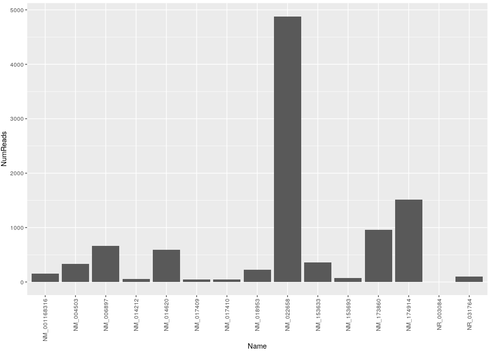

```r
library(ggplot2)
counts <- read.table("docker_exercise/sample_counts/quant.sf", header = T)
ggplot(counts, aes(x = Name, y = NumReads)) +
  geom_bar(stat = "identity") +
  theme(axis.text.x = element_text(angle = 90, vjust = 0.5, hjust=1))
```

6. Push this image to Docker Hub
- HINT: Make sure you create a repository on Docker Hub before pushing.

[figure not shown]

```bash
# Code in terminal

# log in and provide credentials used to sign into Docker Hub
# this will prompt you to enter username and password
docker login -u username

# get image ID to tag and push
docker images
```

```bash
# tag the image you want to push with your Docker Hub username and a tag name after the colon
# the ID is from the 'docker images' command
docker tag 2c5152e60109 rubrc/rstudio_4.4.0_salmon:topush

# push to Docker Hub
docker push rubrc/rstudio_4.4.0_salmon:topush
```